# Stock-Selection-Analysis

Paul Adams & Jeff Nguyen

3/17/2020

```r
library(pacman)
p_load(tswge, dplyr, kableExtra, sqldf, ggplot2, orcutt, tswgewrapped, readr)
```

# Project Data Description

In this project, we analyze 3,202 stock price and volume data time series traded on the NASDAQ exchange between May 30th and October 30th, 2019. This date range was selected for its distance from significant biological and political disruption to the markets, which can both introduce artificial seasonality and increased random variation into forecasts. Data was sourced as comma-separated values through API from AlphaVantage.

Because of the time constraints involved with directly analyzing each stock, we developed a loop to process through each file, perform a linear model on each stock and where the slope for price is positive and greater than 0.04 and the price is within an affordable range - between 5 and 50 dollars per share - we then select that stock to assess if the spectral density indicates any wandering behavior based on a peak at zero and no additional peaks thereafter. Because of this wandering, the sample ACFs were also expected to damp exponentially, indicative of non-stationary behavior. This method allowed us to identify ideal stocks for signal-plus-noise modeling with postive, profitable trending. This method provided us 7 stocks we deemed useful, from which we selected one. The one we chose appeared to provide the most stationary noise around the signal.

This method uses linear regression to identify a profitable signal-plus-noise model fit. Cochran-orcutt is needed after selection of stocks.

# Data Selection

```r
plotts.sample.wge(df$low, trunc=25, arlimits=T)
files = list.files(path='../Time-Series-Stocks', pattern='*.csv')

for(file in files){
  actualFile <- paste0('../Time-Series-Stocks/',file)

  df <- read.csv(actualFile, header=T, strip.white=T)

  # run linear regression to get the signal (average).
  t = seq(1, nrow(df),1)
  fit = lm(df$low~t)

  # get the frequency values from the spectral density in the Parzen Window (we want them to wander without season; just trend)
  dbz <- plotts.sample.wge(df$low)[4] # plotting sample plots to see the stocks while they process

  # if the linear coefficient (deterministic signal) for the price is positive and the price is between 5 and 50 (affordable):
  if(fit$coefficients[2] > 0.04 && df$low[nrow(df)] > 5 && df$low[nrow(df)] < 50){
    for(i in 1:(length(dbz$dbz)-1)){
      # if the realization is wandering (based on spectral density):
      if(dbz$dbz[i] > dbz$dbz[i+1]){
        write.table(df$symbol, './models_aic_less_than_0.csv', append=T)
      }
    }
  }
}
```

# Signal-Plus-Noise Model

In this Signal-Plus-Noise model, we perform a hypothesis test on the linear trend to identify using OLS if the trend is possibly deterministic. After positive confirmation from OLS, we then tested this with the Cochrane-Orcutt AR(1) based hypothesis test, which accounts for serial correlation in determining slope significance. This test also confirmed the signal is a deterministic trend.

Next, we removed the residuals from the trend line and built a model for this data. We then tested the residuals for white noise variance using the Ljung-Box test, which indicated there is not enough evidence to consider the residuals to be more than white noise. Because of the stationarity of the residuals, we were able to estimate a model using the linear slope and adding to it the variation of the residuals.

```r
urlfile="https://raw.githubusercontent.com/PaulAdams4361/Time-Series-Project/master/NASDAQ_Daily_ACGL.csv"
df <- read_csv(url(urlfile))
```

```r
#df <- read.csv('./NASDAQ_Daily_ACGL.csv', header=T, strip.white=F)

# take a sample of the data, analyze
# plotts.sample.wge(df$low, arlimits=T)

####################
# Signal-Plus-Noise
####################
x = df$low
n = length(x)
t = 1:n
fit = lm(x ~ t)
summary(fit) # there appears to be deterministic trend based on OLS; the p-value is significant so reject the null that it is not
```

```
##
## Call:
## lm(formula = x ~ t)
##
## Residuals:
##      Min       1Q   Median       3Q      Max
## -1.10389 -0.52398 -0.02693  0.34676  1.35981
##
## Coefficients:
##              Estimate Std. Error t value Pr(>|t|)
## (Intercept) 34.855438   0.123444  282.36   <2e-16 ***
## t            0.072922   0.002122   34.36   <2e-16 ***
## ---
## Signif. codes:  0 '***' 0.001 '**' 0.01 '*' 0.05 '.' 0.1 ' ' 1
##
## Residual standard error: 0.6126 on 98 degrees of freedom
## Multiple R-squared:  0.9234, Adjusted R-squared:  0.9226
## F-statistic:  1181 on 1 and 98 DF,  p-value: < 2.2e-16
```

```r
# deterministic. The null argues that any present trend is random that will eventually traverse such a pattern that the realization
# will continue to approximate around the mean.

# Because OLS is not robust to non-stationarity, we apply the Cochrane-Orcutt test to also test the beta coefficient slope of time
# using an aproach that fits an AR(1) model to the residuals:
cfit = cochrane.orcutt(fit) # to confirm with chochrane-orcutt
summary(cfit) # Cochran-Orcutt also provides a significant p-value. Based on this, we assume the slope is not equal to zero and
```

```
## Call:
## lm(formula = x ~ t)
##
##               Estimate Std. Error t value  Pr(>|t|)
## (Intercept) 35.0451902  0.3933902  89.085 < 2.2e-16 ***
## t            0.0698107  0.0063528  10.989 < 2.2e-16 ***
## ---
## Signif. codes:  0 '***' 0.001 '**' 0.01 '*' 0.05 '.' 0.1 ' ' 1
##
## Residual standard error: 0.366 on 97 degrees of freedom
## Multiple R-squared:  0.5546 ,  Adjusted R-squared:  0.55
## F-statistic: 120.8 on 1 and 97 DF,  p-value: < 9.97e-19
##
## Durbin-Watson statistic
## (original):    0.39519 , p-value: 1.096e-16
## (transformed): 1.49316 , p-value: 3.732e-03
```

```r
# therefore, there is deterministic that justifies fitting a signal-plus-noise model instead of an ARMA(p,q). However, ARMA(p,q)
# will be fitted later for comparison.

#x.z = x - fit$coefficients[1] - fit$coefficients[2]*t # derive residuals
x.z = fit$residuals # derive residuals (from the regression line)
ar.z = aic.wge(x.z, p=0:6, type="aic") # find a model to use for approximating the residuals. NOTE: (sigmaHAT_a)^2 = 0.1177843
# ar.z$p is the order p (aic selects p=2 where q=0, as does the bic)

# Transform the stock prices by the autoregressive coefficients of the fitted residuals from the linear regression model.
# Remove phi from residuals to remove serial correlation and allow us to model
y.trans = artrans.wge(df$low, phi.tr=ar.z$phi)
```

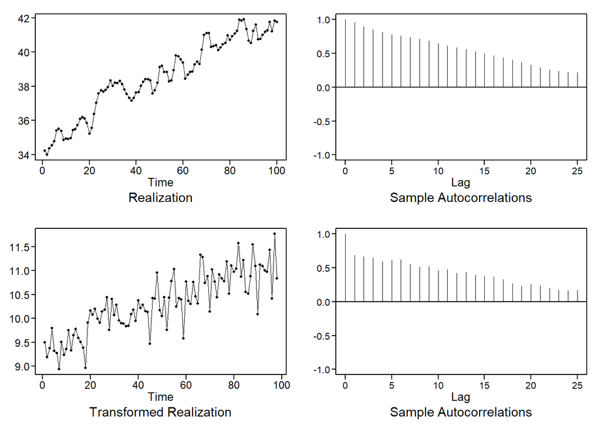

Signal-Plus-Noise Model

```r
# also, transform the predictor variable (time) by the autogregressive coefficeints of the fitted residuals as well
t.trans  = artrans.wge(t, phi.tr=ar.z$phi)
```

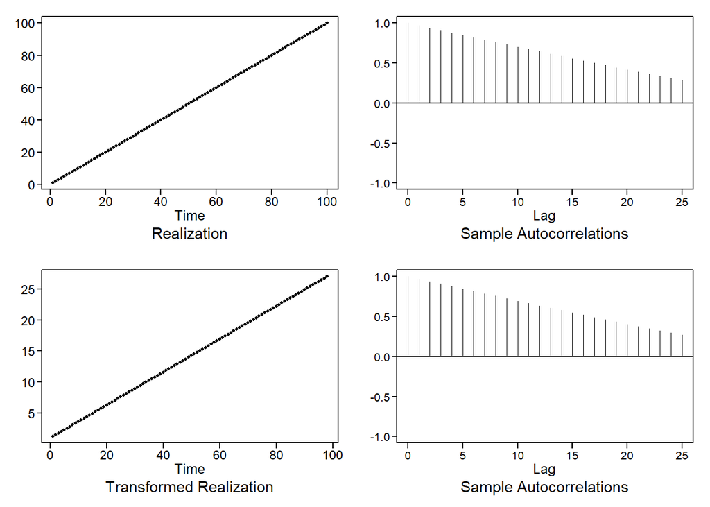

Signal-Plus-Noise Model

```r
# Finally, regress the newly transformed stock prices (Y-HAT_t) on the transformed time (T-HAT_t)using ordinary least squares
fitco = lm(y.trans ~ t.trans)
summary(fitco) # check to see if the transformed beta coefficient for the slope is still significant
```

```
##
## Call:
## lm(formula = y.trans ~ t.trans)
##
## Residuals:
##      Min       1Q   Median       3Q      Max
## -0.97241 -0.18510  0.01497  0.20566  0.70938
##
## Coefficients:
##             Estimate Std. Error t value Pr(>|t|)
## (Intercept) 9.320641   0.074125  125.74   <2e-16 ***
## t.trans     0.070037   0.004634   15.11   <2e-16 ***
## ---
## Signif. codes:  0 '***' 0.001 '**' 0.01 '*' 0.05 '.' 0.1 ' ' 1
##
## Residual standard error: 0.3452 on 96 degrees of freedom
## Multiple R-squared:  0.7041, Adjusted R-squared:  0.701
## F-statistic: 228.4 on 1 and 96 DF,  p-value: < 2.2e-16
```

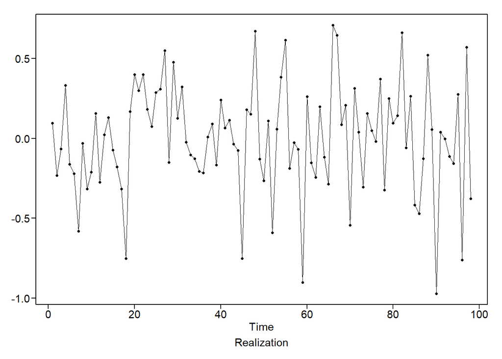

Signal-Plus-Noise Model

```r
# Evaluating the residuals after Cochrane-Orcutt:
plotts.wge(fitco$residuals)
```

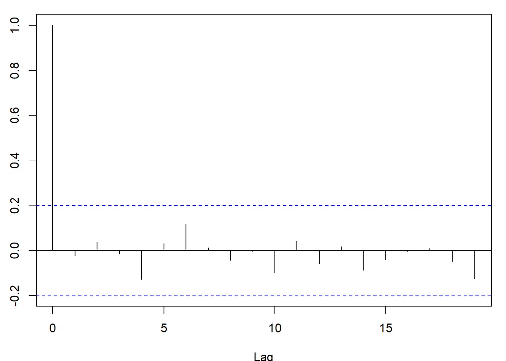

Signal-Plus-Noise Model

```r
acf(fitco$residuals) # residuals appear to be white noise
```

```r
ljung.wge(fitco$residuals) # there is not enough evidence based on the ljung-box test to reject the null hypothesis. Therefore,
```

```
## Obs -0.02329353 0.03696201 -0.0148023 -0.1264051 0.02979692 0.1170724 0.0121294 -0.04358782 -0.004767952 -0.09739137 0.04153028 -0.05785741 0.01704484 -0.08708388 -0.04190725 -0.00537386 0.008676478 -0.04774231 -0.123505 0.02173201 -0.01302386 -0.09454542 -0.1174163 -0.0818482
```

```
## $test
## [1] "Ljung-Box test"
##
## $K
## [1] 24
##
## $chi.square
## [1] 12.52529
##
## $df
## [1] 24
##
## $pval
## [1] 0.9733174
```

```r
# we cannot assume that the residuals are not white noise.

# Final Signal-Plus-Noise Model: X_t = 34.855438 + 0.072922*t + Z_t, (sigmaHAT_a)^2 = 0.1177843 summary(fit = lm(x ~ t))
# creates the coefficients
ar.z$phi
```

```
## [1]  1.0533533 -0.3193699
```

```r
# (1 - 1.0533533*B + 0.3193699*B^2)*Z_t = a__t. ar.z$phi from AR(2) creates the coeffients and (sigmaHAT_a)^2 = 0.1177843

# BUT, TO REITERATE: Final Signal-Plus-Noise Model is X_t = 34.855438 + 0.072922*t + Z_t, (sigmaHAT_a)^2 = 0.1177843
est_mod = gen.sigplusnoise.wge(100, b0=34.855438, b1 = 0.072922, phi=ar.z$phi, vara=0.1177843)
```

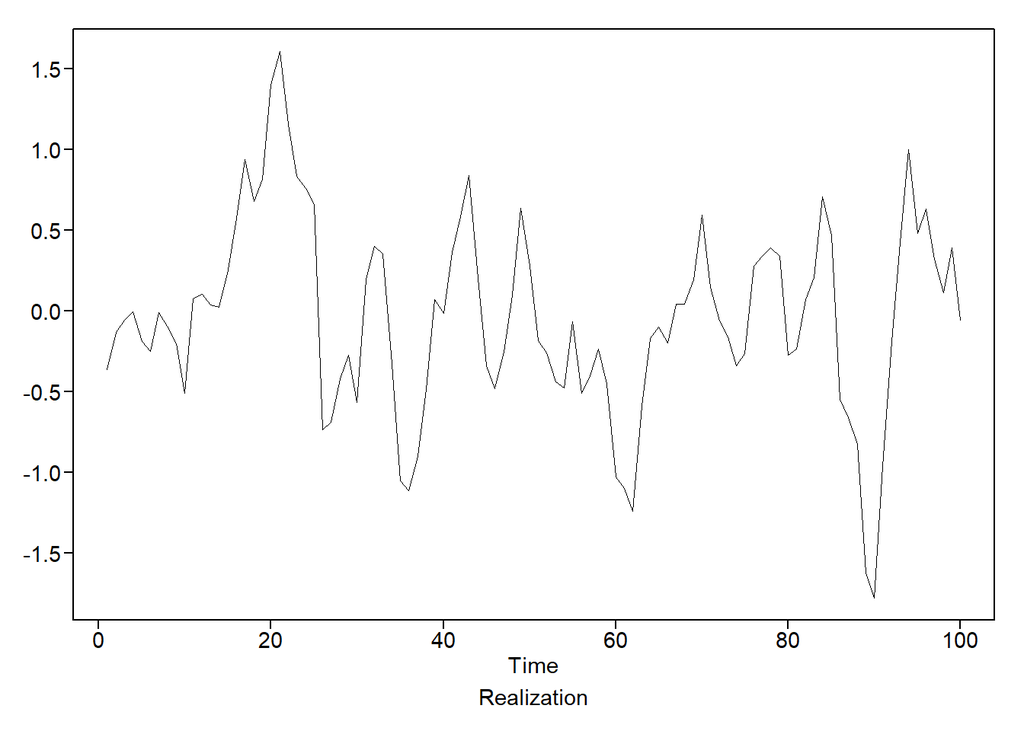

Signal-Plus-Noise Model

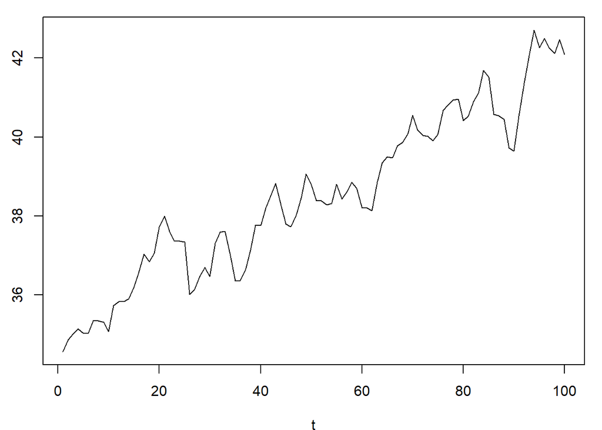

Signal-Plus-Noise Model

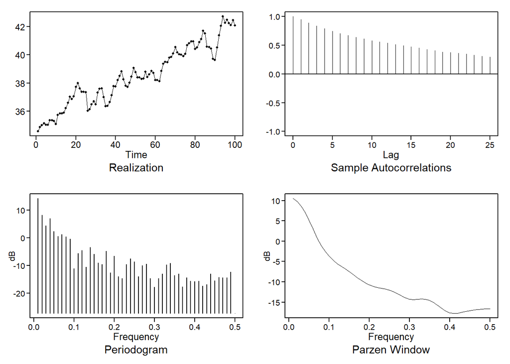

Signal-Plus-Noise Model

[output not shown]

[output cut: 20 more lines]

```r
plotts.sample.wge(est_mod)
```

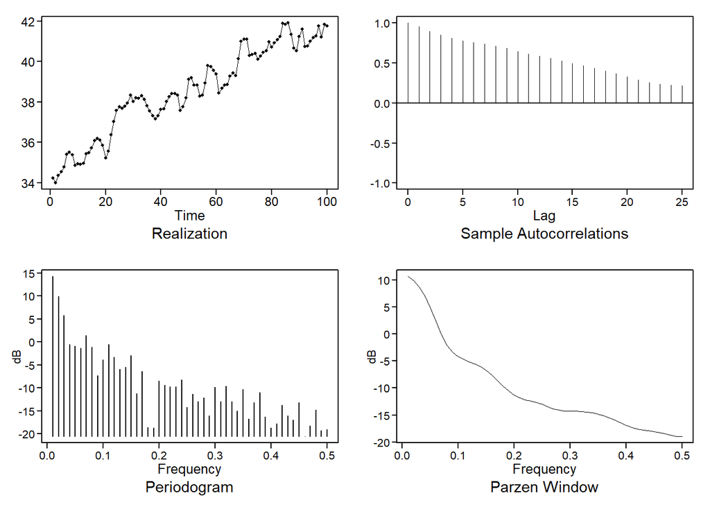

Signal-Plus-Noise Model

[output not shown]

[output cut: 20 more lines]

```r
plotts.sample.wge(df$low) # the estimated model (above) matches to the actual model (here) on both sample ACFs and sample spectral
```

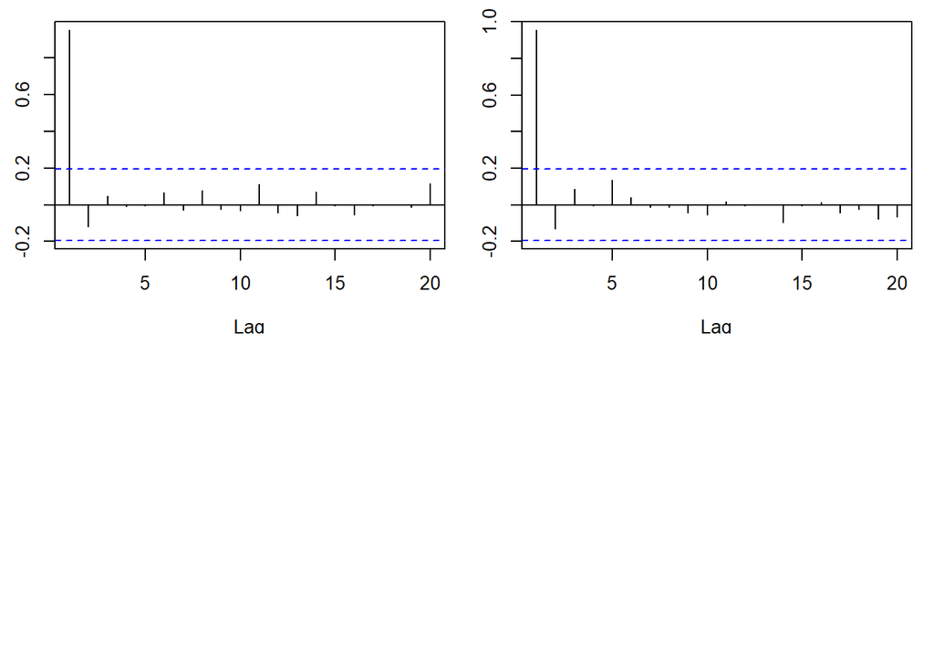

Signal-Plus-Noise Model

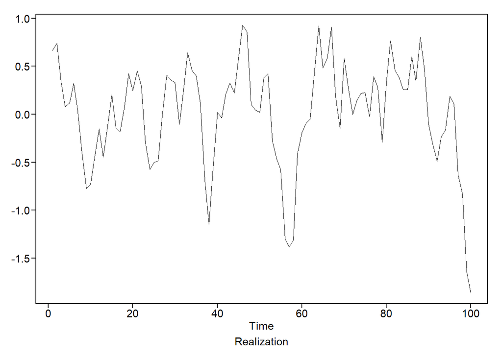

Signal-Plus-Noise Model

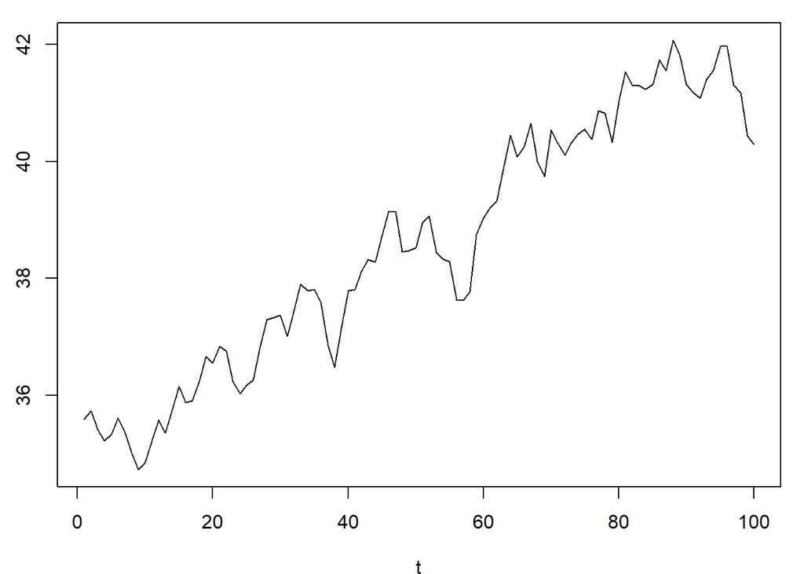

Signal-Plus-Noise Model

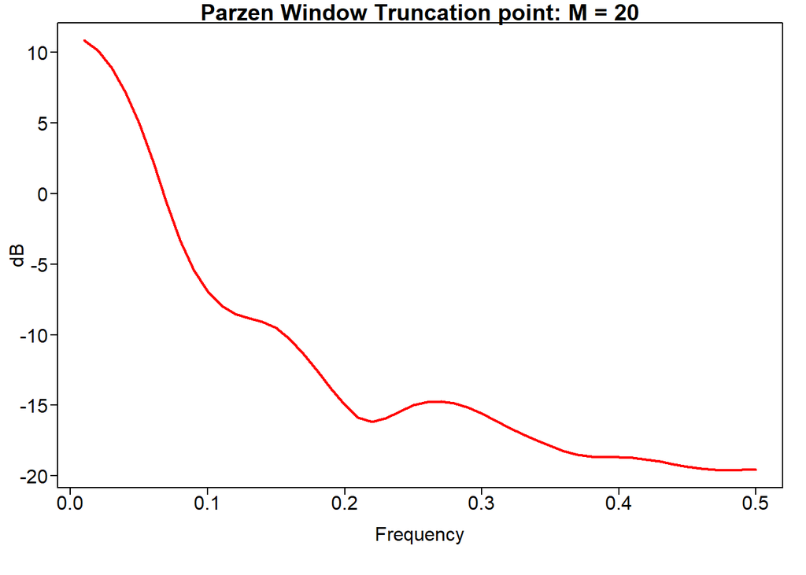

Signal-Plus-Noise Model

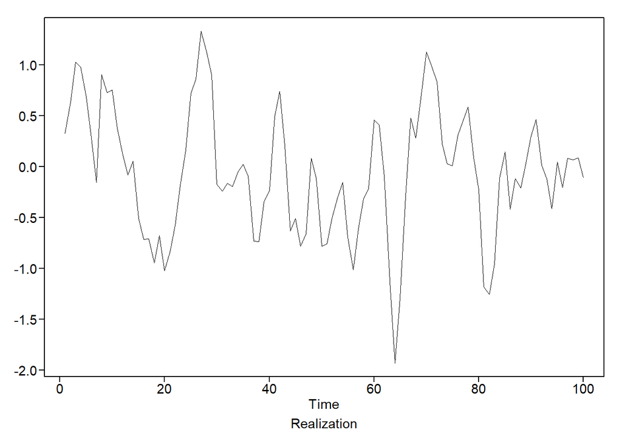

Signal-Plus-Noise Model

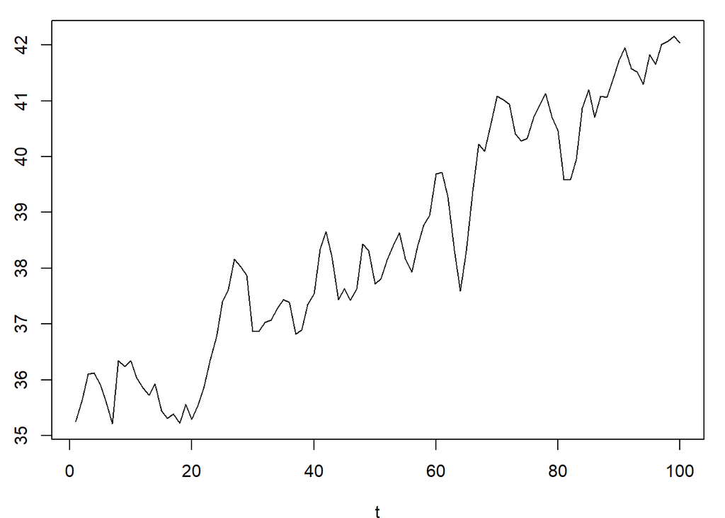

Signal-Plus-Noise Model

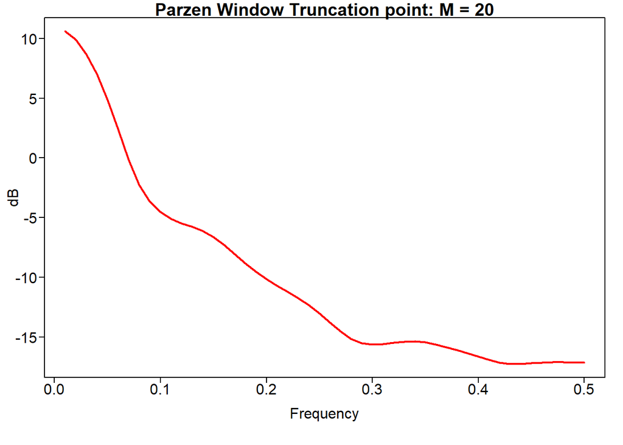

Signal-Plus-Noise Model

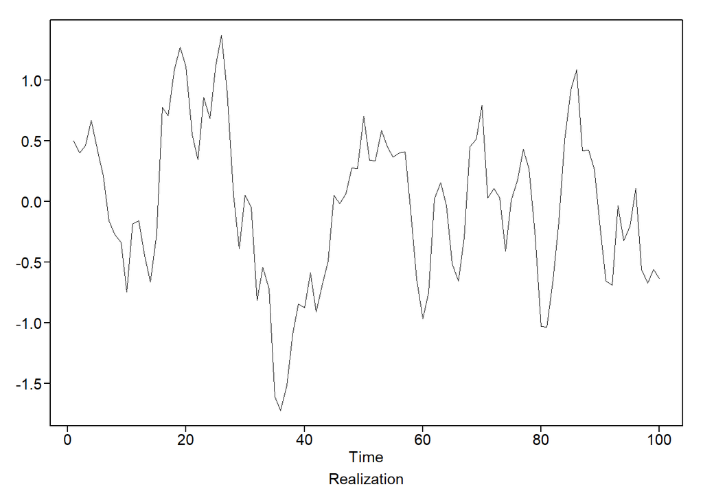

Signal-Plus-Noise Model

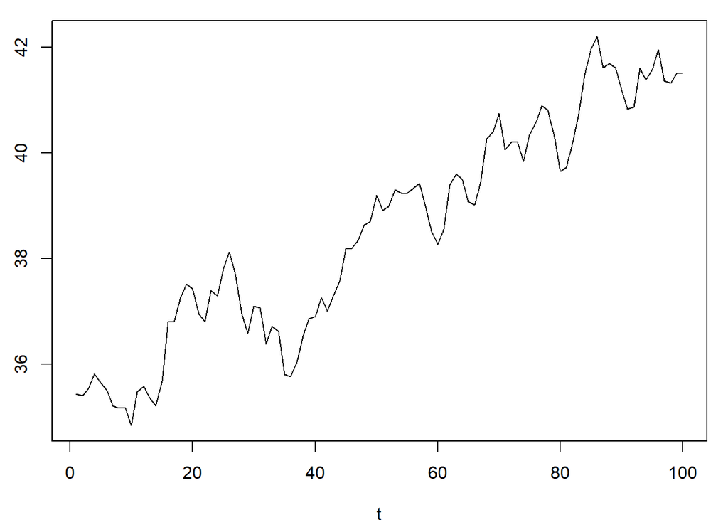

Signal-Plus-Noise Model

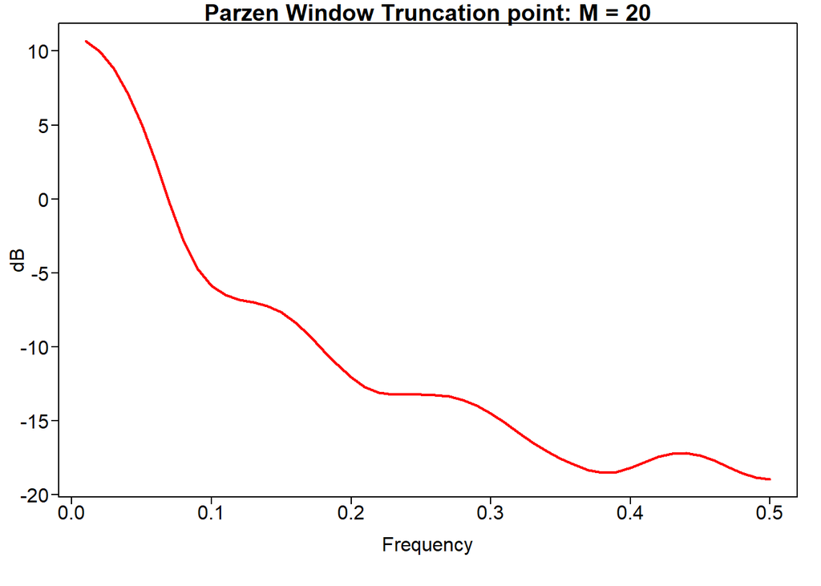

Signal-Plus-Noise Model

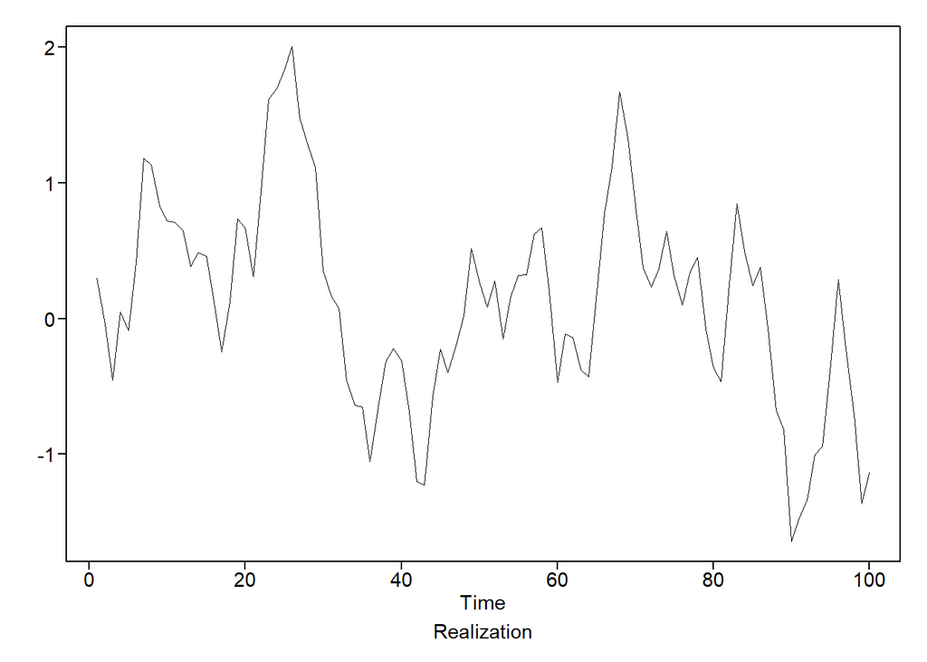

Signal-Plus-Noise Model

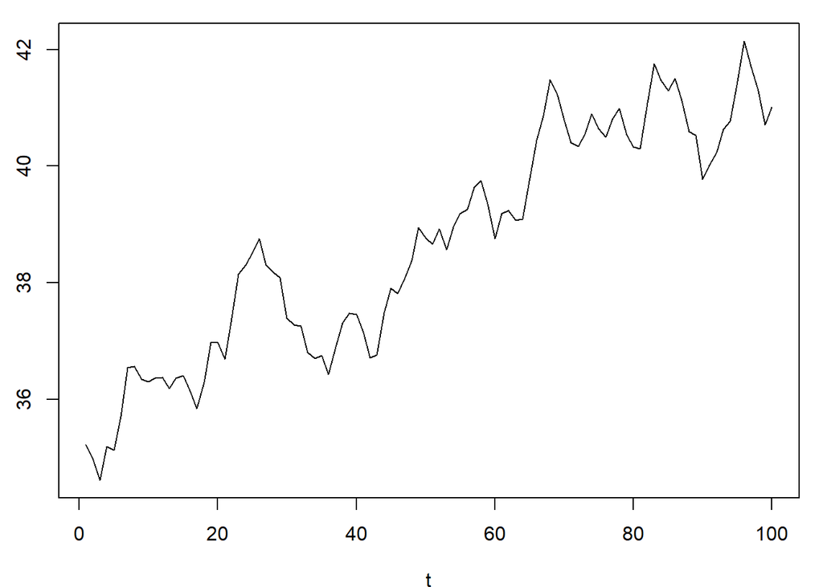

Signal-Plus-Noise Model

[4 more figures not shown]

```r
# density as well as on partial ACF (below):
pacf(est_mod)
pacf(df$low)

#########################################################################################################
############### Confirmation for repeated model visualization of ACF and Spectral Density ###############
#########################################################################################################
for( i in 1: 5)
{
   SpecDen2 = parzen.wge(gen.sigplusnoise.wge(100, b0=34.855438, b1 = 0.072922, phi=ar.z$phi, vara=0.1177843), plot = T)
   lines(SpecDen2$freq,SpecDen2$pzgram, lwd = 2, col = "red")
}
```

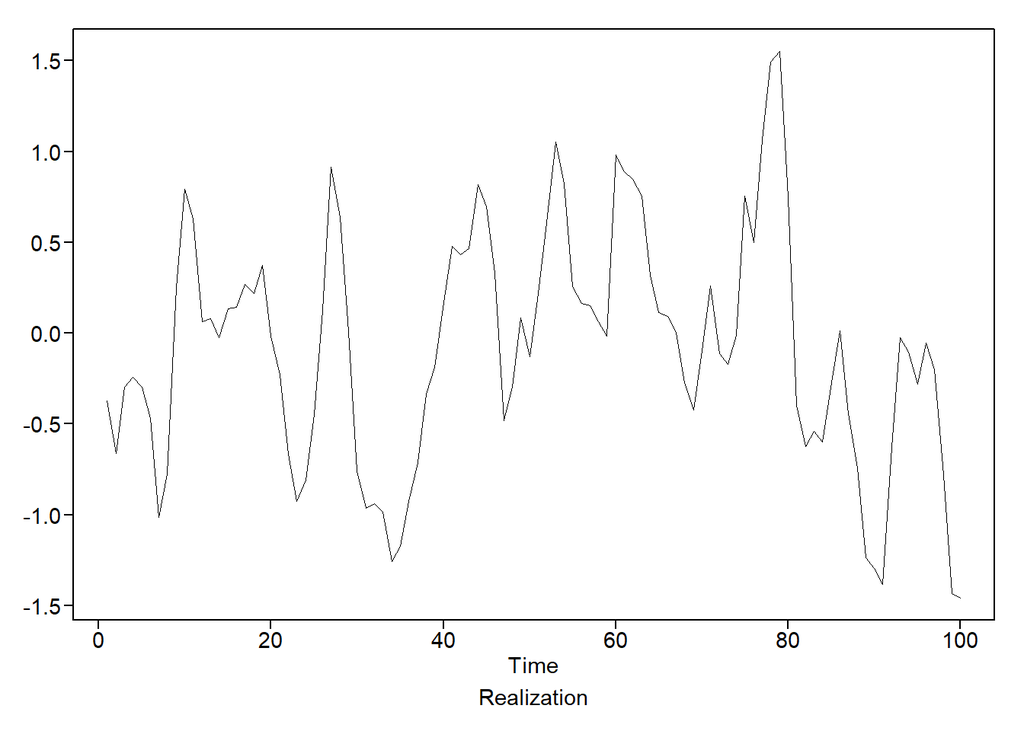

Signal-Plus-Noise Model

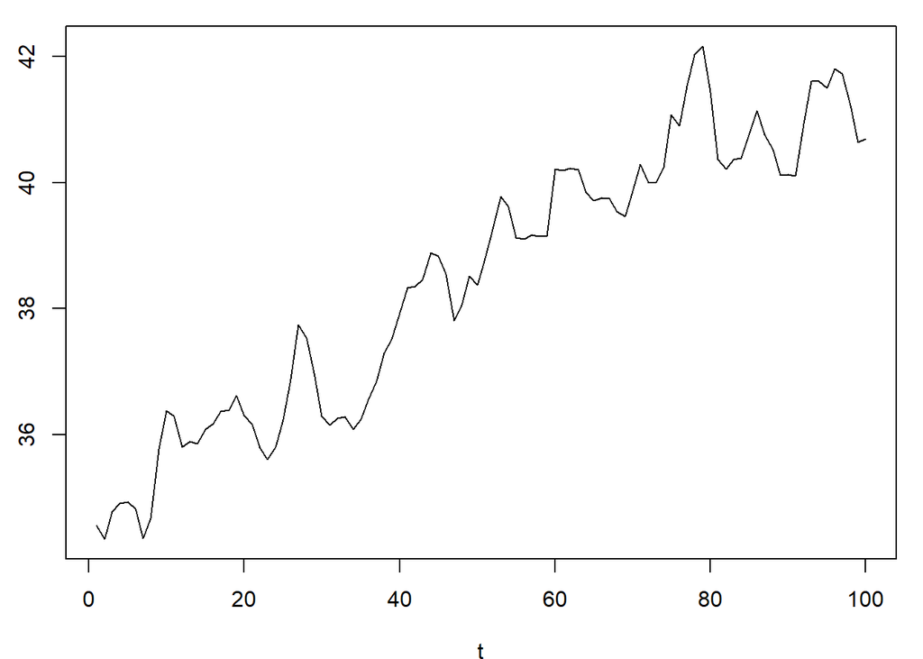

Signal-Plus-Noise Model

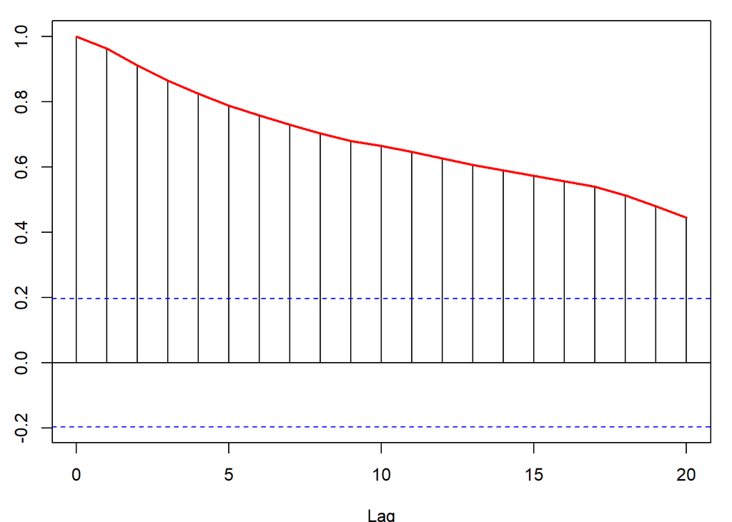

Signal-Plus-Noise Model

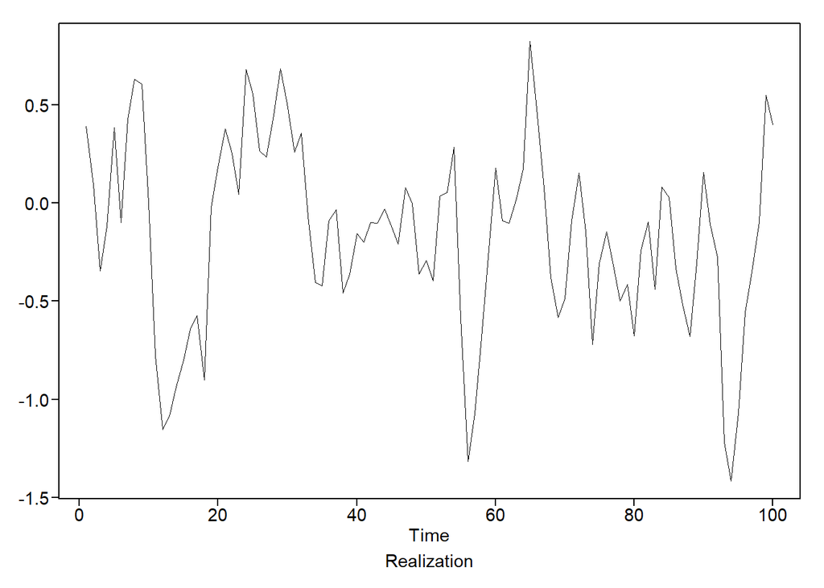

Signal-Plus-Noise Model

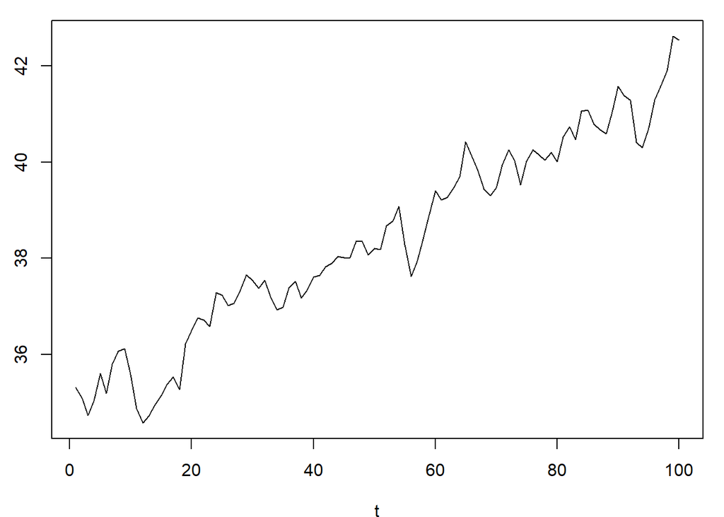

Signal-Plus-Noise Model

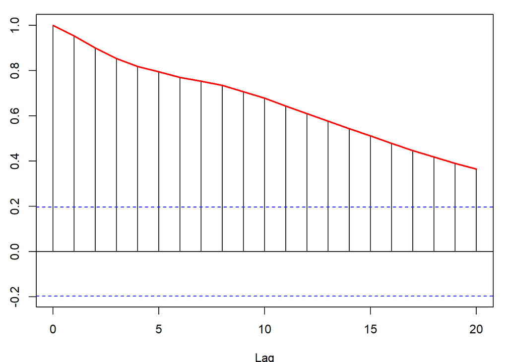

Signal-Plus-Noise Model

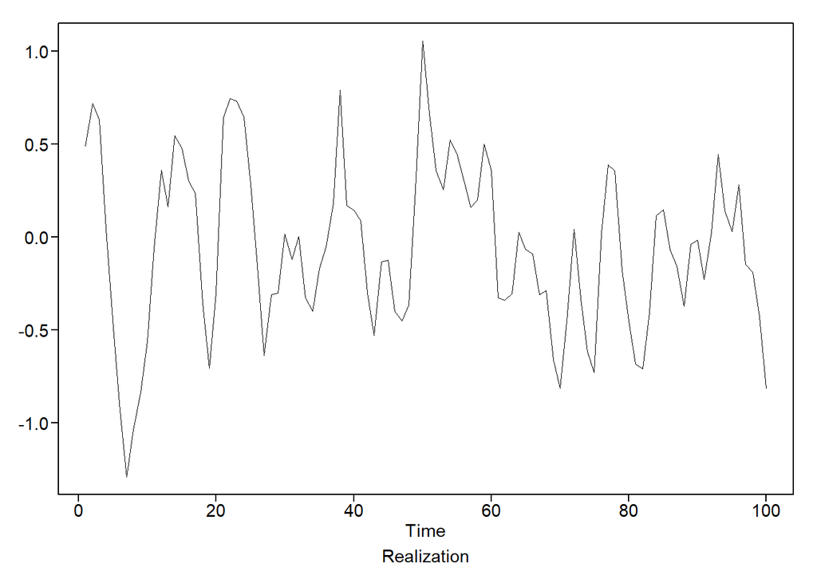

Signal-Plus-Noise Model

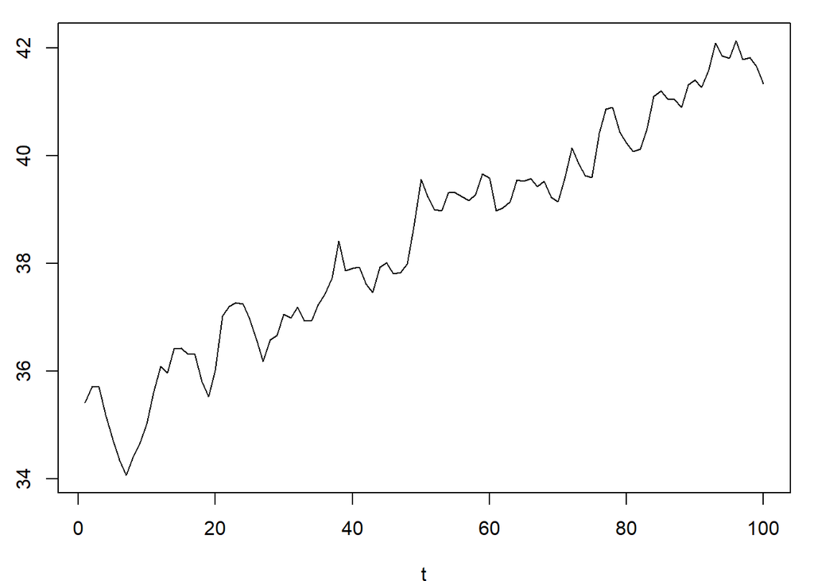

Signal-Plus-Noise Model

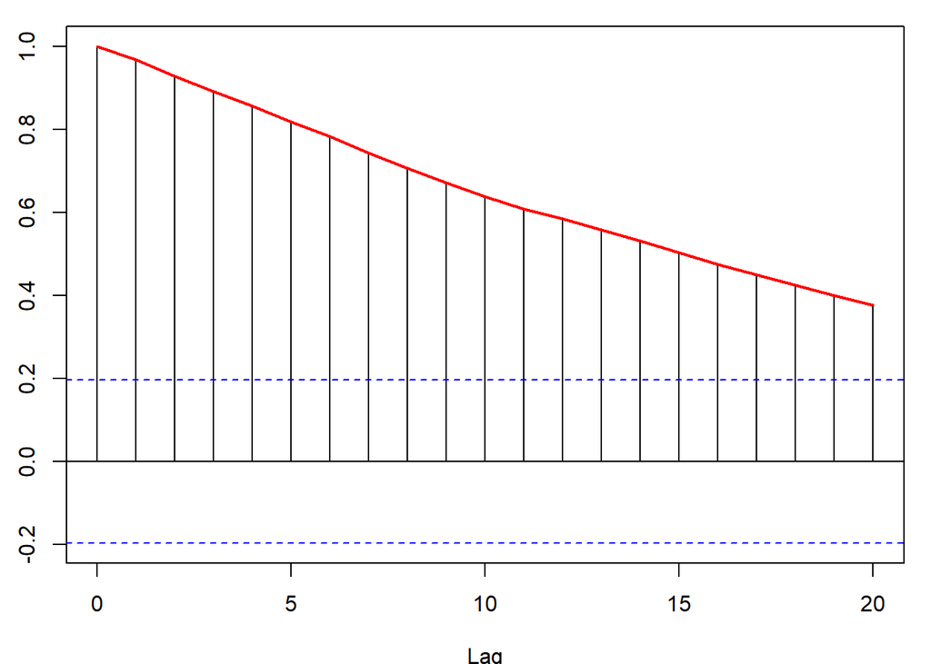

Signal-Plus-Noise Model

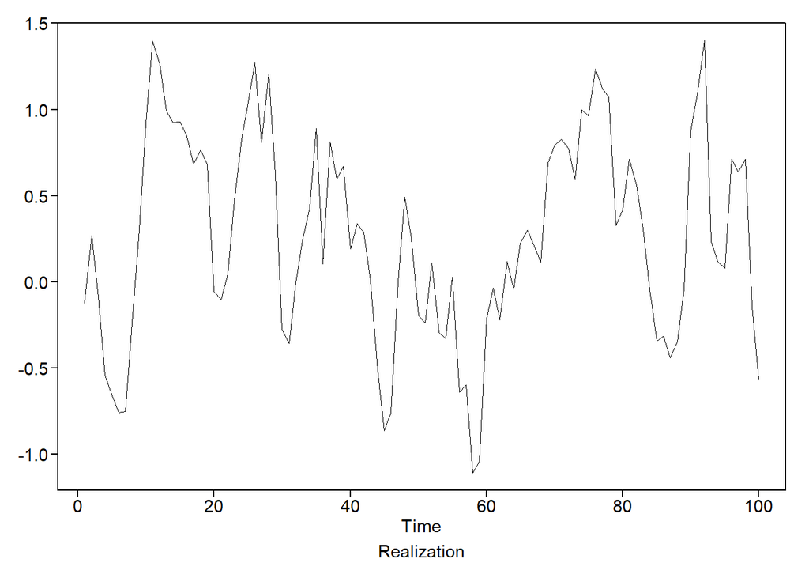

Signal-Plus-Noise Model

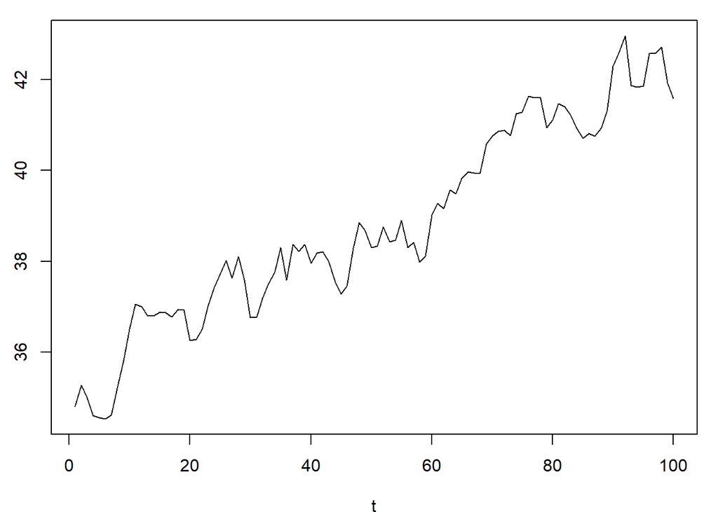

Signal-Plus-Noise Model

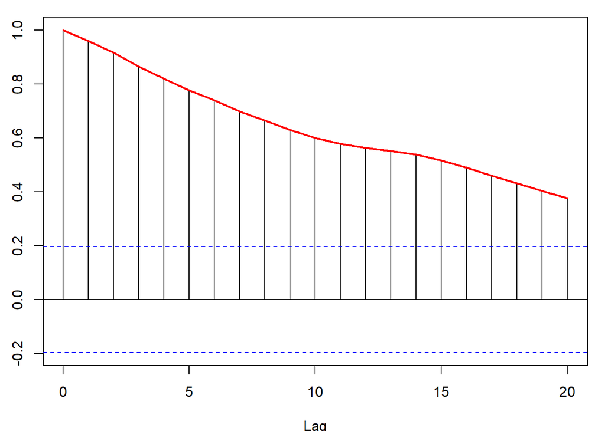

Signal-Plus-Noise Model

[3 more figures not shown]

```r
for( i in 1: 5)
{
   ACF2 = acf(gen.sigplusnoise.wge(100, b0=34.855438, b1 = 0.072922, phi=ar.z$phi, vara=0.1177843), plot = T)
   lines(ACF2$lag ,ACF2$acf, lwd = 2, col = "red")
}
```